# Bayesian Modelling of Gaussian Processes and Hidden Markov Models with Stan

## Setup

Let’s set up our computing environment:

```r
setwd("~/Code/hmm-vs-gp")

# Packages
library(rstan)
```

```r
library(ggplot2)
library(bayesplot)
library(invgamma)
rstan_options(auto_write = TRUE)
options(mc.cores = parallel::detectCores())
seed = 723456

# Colors
c_light <- c("#DCBCBC")
c_mid <- c("#B97C7C")
c_dark <- c("#8F2727")
c_blue_light <- c("#b2c4df")
c_blue_mid <- c("#6689bf")
c_blue_dark <- c("#3d5272")
color_scheme_set("red")
```

## Gaussian Processes

### Priors

For the length scale parameter ($\rho$) we use an inverse gamma prior with $\alpha=2$ and $\beta=0.5$.

$$\frac{1}{\rho} \sim \text{Gamma}(\alpha=2, \beta=0.5)$$

This results in a distribution which is defined $>0$, and has a low density near zero and at higher values.

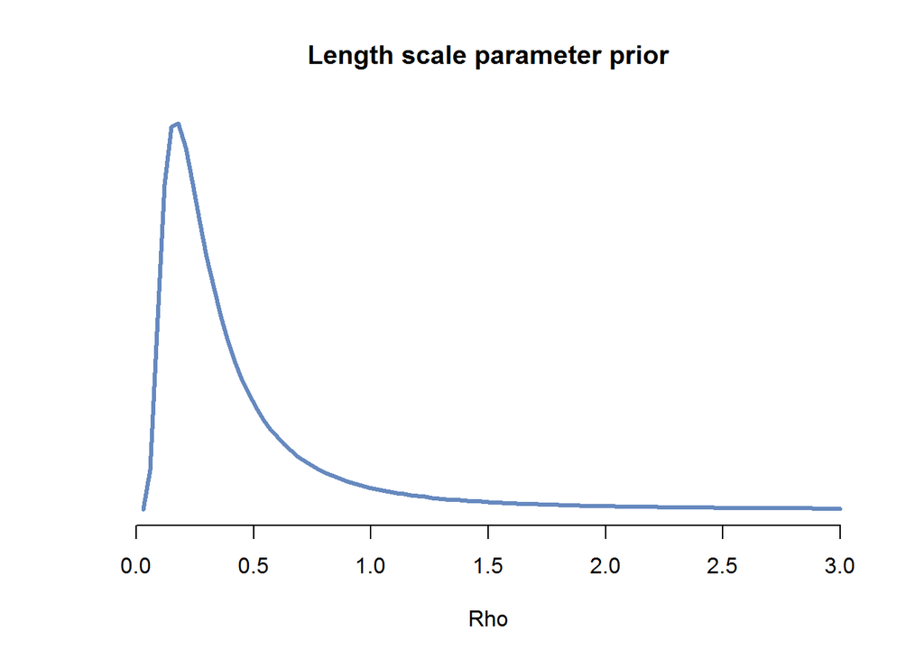

```r
rho_prior <- function(x) dinvgamma(x, 2, 1/2)
plot(rho_prior, 0, 3, xlab='Rho', ylab='',
     main="Length scale parameter prior",
      yaxt='n', bty='n', lwd=3, col=c_blue_mid)
```

For the signal standard deviation parameter ($\alpha$, aka “marginal” standard deviation or “ouput” standard deviation) we use a half-normal prior (a normal distribution but with zero density $<0$) with $\sigma=2$.

$$\alpha \sim \mathcal{N}(\mu=0, \sigma=2), ~ \alpha \geq 0$$

This results in a distribution which is defined $>0$, and has a low density at higher values.

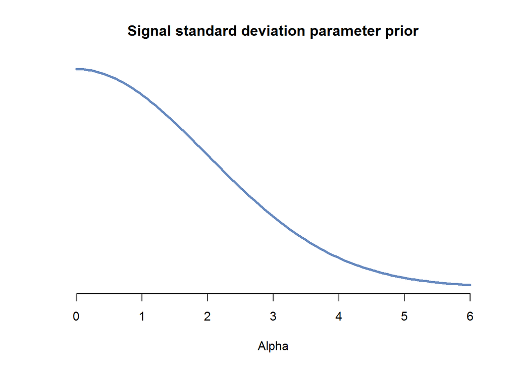

```r
alpha_prior <- function(x) 2*dnorm(x, 0, 2)
plot(alpha_prior, 0, 6, xlab='Alpha', ylab='',
     main="Signal standard deviation parameter prior",
      yaxt='n', bty='n', lwd=3, col=c_blue_mid)
```

For the noise standard deviation parameter ($\sigma$) we also use a half-normal prior, but with $\sigma=1$.

$$\sigma \sim \mathcal{N}(\mu=0, \sigma=1), ~ \alpha \geq 0$$

This results in a distribution which is defined $>0$, and has a low density at higher values.

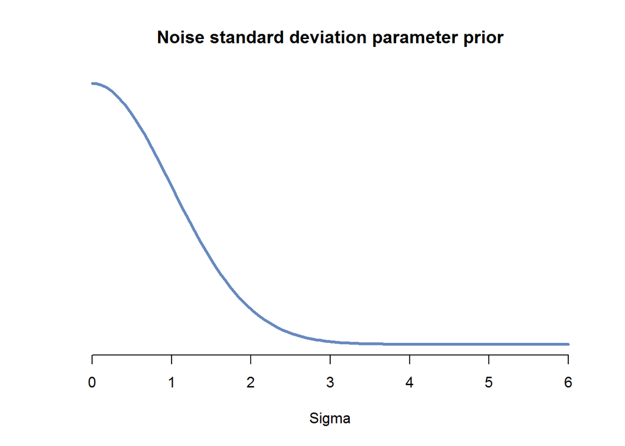

```r
sigma_prior <- function(x) 2*dnorm(x, 0, 1)
plot(sigma_prior, 0, 6, xlab='Sigma', ylab='',
     main="Noise standard deviation parameter prior",
      yaxt='n', bty='n', lwd=3, col=c_blue_mid)
```

### Generating Data from a Gaussian Process

```r
writeLines(readLines("simulate_lgp.stan"))
```

```
## data {
##     int<lower=1> N;      //number of datapoints
##     real x[N];           //x values
##
##     real<lower=0> rho;   //length scale
##     real<lower=0> alpha; //marginal/output/signal standard deviation
##     real<lower=0> sigma; //noise standard deviation
## }
##
## transformed data {
##     matrix[N, N] K = cov_exp_quad(x, alpha, rho)
##                      + diag_matrix(rep_vector(1e-10, N));
##     matrix[N, N] L_K = cholesky_decompose(K);
## }
##
## parameters {}
##
## model {}
##
## generated quantities {
##     // Declare variables
##     vector[N] uf;
##     vector[N] uy;
##     vector[N] f;
##     vector[N] y;
##
##     // Function and samples in untransormed space
##     uf = multi_normal_cholesky_rng(rep_vector(0, N), L_K);
##     for (i in 1:N)
##         uy[i] = normal_rng(uf[i], sigma);
##
##     // Logit function and samples
##     f = inv_logit(uf);
##     y = inv_logit(uy);
## }
```

We can generate data from a Gaussian process using this Stan model. Let’s generate 100 samples in the range 0 to 5.

```r
# Data
N = 100
x = seq(0, 5, l=N)
```

We will also set the hyperparameters of the gaussian process.

```r
# Parameters
rho = 0.5
alpha = 2
sigma = 0.3
```

Now we can run the Stan model, which will generate data from a Gaussian process with these parameters.

```r
# Simulate
sim_params = list(N=N, x=x, rho=rho, alpha=alpha, sigma=sigma)
sim_fit = stan(file='simulate_lgp.stan', data=sim_params, iter=1,
               chains=1, seed=seed, algorithm="Fixed_param")
```

```
##
## Iteration: 1 / 1 [100%]  (Sampling)
##
##  Elapsed Time: 0 seconds (Warm-up)
##                0.001 seconds (Sampling)
##                0.001 seconds (Total)
```

```r
# Extract simulated output
f = extract(sim_fit)$f[1,]
y = extract(sim_fit)$y[1,]
sim_data = data.frame(x=x, y=y, f=f)
```

Let’s plot our generated Gaussian process:

```r
# Plot generated data
ggplot(sim_data) +
  geom_line(aes(x=x, y=f), size=1) +
  geom_point(aes(x=x, y=y), color=c_mid) +
  ggtitle('Simulated Gaussian Process')
```

[figure not shown]

The line above is the latent function which was generated, and the dots are the generated observations. Notice how the latent function varies smoothly over time, and varies between 0 and 1. The observations have more jitter than the latent function (because they are generated from that function but with added noise), but each point is in the neigborhood of the previous point, and they are also bounded between 0 and 1.

### Fitting a Gaussian Process

Now that we’ve generated some data from a Gaussian process, we can attempt to fit a Gaussian process model to that data. We’ll use a separate Stan model, one which fits the parameters of the model to the data, instead of generating data from the parameters.

```r
writeLines(readLines("lgp.stan"))
```

```
## data {
##     int<lower=1> N;                 //number of datapoints
##     real x[N];                      //x values
##     vector<lower=0, upper=1>[N] y;  //y values (one N-dim datapoint)
## }
##
## transformed data {
##     vector[N] mu = rep_vector(0, N);
## }
##
## parameters {
##     real<lower=0> rho;   //length scale
##     real<lower=0> alpha; //marginal/output/signal standard deviation
##     real<lower=0> sigma; //noise standard deviation
## }
##
## model {
##     // Decomposed covariance matrix
##     matrix[N, N] K = cov_exp_quad(x, alpha, rho)
##                      + diag_matrix(rep_vector(square(sigma), N));
##     matrix[N, N] L_K = cholesky_decompose(K);
##
##     // Priors
##     target += inv_gamma_lpdf(rho | 2, 0.5);
##     target += normal_lpdf(alpha | 0, 2);
##     target += normal_lpdf(sigma | 0, 1);
##
##     // Likelihood
##     target += multi_normal_cholesky_lpdf(logit(y) | mu, L_K);
##
##     // TODO: do you have to multiply those normal_lpdf values by 2? (b/c of half-normal dist) - don't want to mess up the bridge sampler...
##     // TODO: handle multiple trials
##     // TODO: multilevel model to handle multiple subjects
## }
```

Let’s fit the model to our generated data.

```r
# Fit
stan_rdump(c("N", "x", "y"), file="simulated_lgp.data.R")
fit_data = read_rdump("simulated_lgp.data.R")
fit = stan(file='lgp.stan', data=fit_data, seed=seed)
```

```
## recompiling to avoid crashing R session
```

[output not shown]

After MCMC sampling has finished, we can view the posterior intervals for each parameter.

```r
# Show results of fit
print(fit)
```

```
## Inference for Stan model: lgp.
## 4 chains, each with iter=2000; warmup=1000; thin=1;
## post-warmup draws per chain=1000, total post-warmup draws=4000.
##
##         mean se_mean   sd   2.5%    25%    50%    75%  97.5% n_eff Rhat
## rho     0.49    0.00 0.05   0.38   0.45   0.49   0.52   0.59  2559    1
## alpha   1.91    0.01 0.48   1.20   1.57   1.83   2.16   3.05  2104    1
## sigma   0.31    0.00 0.02   0.27   0.30   0.31   0.33   0.36  2365    1
## lp__  -59.25    0.03 1.23 -62.47 -59.81 -58.92 -58.36 -57.86  1849    1
##
## Samples were drawn using NUTS(diag_e) at Mon Sep 24 14:52:06 2018.
## For each parameter, n_eff is a crude measure of effective sample size,
## and Rhat is the potential scale reduction factor on split chains (at
## convergence, Rhat=1).
```

Before checking that our fits recover the true parameters which were used to generate the data, we’ll run a few diagnostics to ensure that the MCMC sampling went smoothly and that our model isn’t misspecified.

First, we’ll check that the MCMC chains converged. The `Rhat` value in the table above should be close to 1. The posterior distributions should also look the same across chains.

```r
# Plot density per chain
posterior = as.array(fit)
mcmc_dens_overlay(posterior, pars=c("rho", "alpha", "sigma"))
```

[figure not shown]

The distributions look similar between chains, which is good! This should also be apparent in the trace plot (the plot of posterior sample values vs sample number), and there shouldn’t be any obvious “sliding” over time.

```r
# Plot trace per chain
mcmc_trace(posterior, pars=c("rho", "alpha", "sigma"))
```

[figure not shown]

Again, everything looks good here.

We should also check that none of the iterations hit the max tree depth.

```r
# Check no chains hit max tree depth
check_treedepth(fit)
```

```
## 0 of 4000 iterations saturated the maximum tree depth of 10.
```

Another diagnostic to check is the energy Bayesian fraction of missing information (E-BFMI).

```r
# Check the energy Bayesian Fraction of Missing Information
check_energy(fit)
```

```
## E-BFMI indicated no pathological behavior.
```

Finally, we should check that iterations did not end with a divergence, indicating areas of parameter space that the sampling was not able to explore well.

```r
# Check for divergences
check_divergences(fit)
```

```
## 0 of 4000 iterations ended with a divergence.
```

All our diagnostics seem to indicate that we were able to fit the data without any sampling issues! Now we can see how the posterior distributions for the parameters match up to the true parameters we used to generate the data. First let’s define a function which will plot our posterior distributions from the MCMC samples and their 95% confidence intervals.

```r
# Function to plot posterior distributions w/ 95% confidence intervals
interval_density = function(x, bot=0.025, top=0.975,
                            main="", xlab="", ylab="",
                            xlim=c(min(x),max(x)), lwd=1,
                            col1=c("#DCBCBC"), col2=c("#B97C7C")) {
  dens = density(x)
  plot(dens, main=main, xlab=xlab, ylab=ylab, xlim=xlim,
       lwd=lwd, yaxt='n', bty='n', type='n')
  polygon(dens, col=col1, border=NA)
  qbot <- quantile(x, bot)
  qtop <- quantile(x, top)
  x1 = min(which(dens$x >= qbot))
  x2 = max(which(dens$x < qtop))
  with(dens, polygon(x=x[c(x1,x1:x2,x2)], y=c(0, y[x1:x2], 0), col=col2, border=NA))
}
```

And now we can view the posteriors as compared to the true parameter values which were used to generate the data.

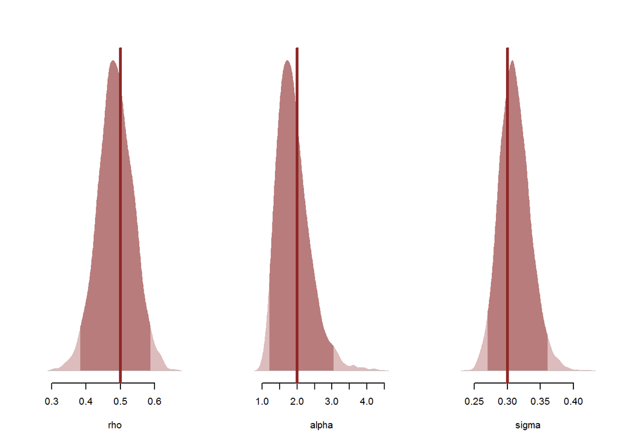

```r
# Plot true vs posterior for rho
posterior = extract(fit)
par(mfrow=c(1, 3))

interval_density(posterior$rho, xlab="rho")
abline(v=rho, col=c_dark, lwd=3)

interval_density(posterior$alpha, xlab="alpha")
abline(v=alpha, col=c_dark, lwd=3)

interval_density(posterior$sigma, xlab="sigma")
abline(v=sigma, col=c_dark, lwd=3)
```

The true parameter values are all within the bulk of the posterior, meaning we were able to successfully recover the true parameters!

## Hidden Markov Models

### The Math

Our model will have two hidden states ($N=2$). This means that our model has two free parameters which control the transition probabilities $\phi$. The probability of transitioning from state $i$ to state $j$ is $\phi_{i,j}$. In our Stan model, we’ll fit the “recurrent” transition probabilities - that is, the probability that the hidden state at the current timestep will be the same as the last timestep. So, the two free parameters which control the transition probabilities are:

$$\phi_{i,i} ~ \text{for} ~ i \in \{1,2\}$$

We model the probability of an observation given the state as a beta distribution. However, for each hidden state, one parameter of the distribution is fixed at $1$, and the other parameter is free. This gives us two additional parameters ($\theta_1$ and $\theta_2$) which control the observation probabilities corresponding to the hidden states. So for the first state $x_1$,

$$y|x_1 \sim \text{Beta}(1, \theta_1)$$

and for the second state $x_2$,

$$y|x_2 \sim \text{Beta}(\theta_2, 1)$$

### Priors

For the observation model parameters ($\theta$) we use a gamma prior with $\alpha,\beta=2$, and limit the values to be $\geq 1$,

$$\theta_i - 1 \sim \text{Gamma}(\alpha=2, \beta=2)$$

This results in a distribution which has zero density $<1$, and low density at higher values.

NOTE: could also use a log-Cauchy distribution ($\theta \sim 1/(log(x)^2+1)$)? Same bounds, has ridiculously long tail on the positive end…

```r
theta_prior <- function(x) dgamma(x-1, 2, 1/2)
plot(theta_prior, 0, 10, xlab='Theta', ylab='',
     main="Observation model parameter prior",
      yaxt='n', bty='n', lwd=3, col=c_blue_mid)
```

[figure not shown]

For the recurrent transition probability prior, we use a beta distribution with $\alpha,\beta=2$,

$$\phi_{i,i} \sim \text{Beta}(2, 2)$$

This results in a distribution which is bounded between $0$ and $1$, and has lower density towards more extreme values.

```r
trans_prior <- function(x) dbeta(x, 2, 2)
plot(trans_prior, 0, 1, xlab='Phi_{i,i}', ylab='',
     main="Recurrent transition probability prior",
     type='l', yaxt='n', bty='n', lwd=3, col=c_blue_mid)
```

[figure not shown]

### Generating Data from a Hidden Markov Model

```r
writeLines(readLines("simulate_hmm.stan"))
```

```
## // Generates data from a 2-state Hidden Markov Model
## // with Beta-distributed observation probabilities
##
## data {
##   int<lower=1> N;         //number of observations to generate
##   vector[2] phi[2];       //transition probabilities
##   real<lower=0> theta[2]; //observation distribution params
## }
##
## transformed data {
##   real thetas[2,2]; //just so we don't need if/elses in generated quantities...
##   thetas[1,1] = 1;
##   thetas[1,2] = theta[1];
##   thetas[2,1] = theta[2];
##   thetas[2,2] = 1;
## }
##
## parameters {}
##
## model {}
##
## generated quantities {
##
##   // Declare variables
##   real y[N];         //observations
##   int<lower=1> s[N]; //hidden states
##
##   // Generate hidden state sequence and observations
##   s[1] = categorical_rng(rep_vector(0.5, 2)); //start at random state
##   y[1] = beta_rng(thetas[s[1],1], thetas[s[1],2]); //generate observation
##   for (t in 2:N) {
##     s[t] = categorical_rng(phi[s[t-1]]); //new state
##     y[t] = beta_rng(thetas[s[t],1], thetas[s[t],2]); //generate observation
##   }
##
## }
```

We can use this Stan model to generate data from our hidden Markov model. Let’s generate 100 samples.

```r
# Data
N = 100
```

We will also set the parameters of the HMM.

```r
# Parameters
phi = array(c(0.8, 0.2, 0.2, 0.8), dim=c(2,2)) #transition probabilities
theta = c(5, 5) #observation distribution parameters
```

Now we can run the Stan model, which will generate data from a hidden Markov model with these parameters.

```r
# Simulate
sim_params = list(N=N, phi=phi, theta=theta)
sim_fit = stan(file='simulate_hmm.stan', data=sim_params, iter=1,
               chains=1, seed=seed, algorithm="Fixed_param")
```

```
##
## Iteration: 1 / 1 [100%]  (Sampling)
##
##  Elapsed Time: 0 seconds (Warm-up)
##                0 seconds (Sampling)
##                0 seconds (Total)
```

```r
# Extract simulated output
s = t(extract(sim_fit)$s)-1
y = t(extract(sim_fit)$y)
sim_data = data.frame(x=seq(N), s=s, y=y)
```

```r
# Plot generated data
ggplot(sim_data) +
  geom_line(aes(x=x, y=s), size=1) +
  geom_point(aes(x=x, y=y), color=c_mid) +
  ggtitle('Simulated Hidden Markov Model')
```

[figure not shown]

### Fitting a Hidden Markov Model

```r
writeLines(readLines("hmm.stan"))
```

```
## // 2-state Hidden Markov Model
## // with Beta-distributed observation probabilities
##
## data {
##   int<lower=1> N;              //number of observations
##   real<lower=0, upper=1> y[N]; //observations
## }
##
## parameters {
##   simplex[2] phi[2];      //transition probabilities
##   real<lower=1> theta[2]; //observation distribution params
## }
##
## model {
##
##   // Priors
##   target += gamma_lpdf(theta[1]-1 | 2, 2);
##   target += gamma_lpdf(theta[2]-1 | 2, 2);
##   target += beta_lpdf(phi[1,1] | 2, 2);
##   target += beta_lpdf(phi[2,2] | 2, 2);
##
##   // Compute the marginal probability over possible sequences
##   {
##     real acc[2];
##     real gamma[N, 2];
##     gamma[1,1] = beta_lpdf(y[1] | 1, theta[1]);
##     gamma[1,2] = beta_lpdf(y[2] | theta[2], 1);
##     for (t in 2:N) {
##       for (k in 1:2) {
##         acc[1] = gamma[t-1, 1] + log(phi[1,k]) + beta_lpdf(y[t] | 1, theta[1]);
##         acc[2] = gamma[t-1, 2] + log(phi[2,k]) + beta_lpdf(y[t] | theta[2], 1);
##         gamma[t,k] = log_sum_exp(acc);
##       }
##     }
##     target += log_sum_exp(gamma[N]);
##   }
##
##   // TODO: handle multiple trials
##   // TODO: multilevel model to handle multiple subjects
##
## }
```

Let’s fit the model to our generated data.

```r
# Fit
y = y[,1]
stan_rdump(c("N", "y"), file="simulated_hmm.data.R")
fit_data = read_rdump("simulated_hmm.data.R")
fit = stan(file='hmm.stan', data=fit_data, seed=seed)
```

After MCMC sampling has finished, we can view the posterior intervals for each parameter.

```r
# Show results of fit
print(fit)
```

```
## Inference for Stan model: hmm.
## 4 chains, each with iter=2000; warmup=1000; thin=1;
## post-warmup draws per chain=1000, total post-warmup draws=4000.
##
##           mean se_mean   sd  2.5%   25%   50%   75% 97.5% n_eff Rhat
## phi[1,1]  0.75    0.00 0.06  0.62  0.71  0.75  0.79  0.85  4000    1
## phi[1,2]  0.25    0.00 0.06  0.15  0.21  0.25  0.29  0.38  4000    1
## phi[2,1]  0.34    0.00 0.07  0.21  0.29  0.34  0.39  0.49  4000    1
## phi[2,2]  0.66    0.00 0.07  0.51  0.61  0.66  0.71  0.79  4000    1
## theta[1]  5.46    0.01 0.82  3.95  4.87  5.42  6.00  7.12  4000    1
## theta[2]  4.02    0.01 0.74  2.69  3.51  3.99  4.49  5.59  4000    1
## lp__     26.10    0.03 1.46 22.38 25.37 26.39 27.16 27.97  2132    1
##
## Samples were drawn using NUTS(diag_e) at Mon Sep 24 14:52:17 2018.
## For each parameter, n_eff is a crude measure of effective sample size,
## and Rhat is the potential scale reduction factor on split chains (at
## convergence, Rhat=1).
```

Again we’ll check several diagnoistics to ensure our sampling effectively explored the parameter space. The Rhat values look good, and if we look at the posterior distributions per chain, it appears the chains converged.

```r
# Plot density per chain
posterior = as.array(fit)
mcmc_dens_overlay(posterior,
                  pars=c("phi[1,1]", "phi[2,2]", "theta[1]", "theta[2]"))
```

[figure not shown]

The trace plots also indicate that the chains (likely) explored similar areas of parameter space, and that the warmup period was (probably) long enough.

```r
# Plot trace per chain
mcmc_trace(posterior,
           pars=c("phi[1,1]", "phi[2,2]", "theta[1]", "theta[2]"))
```

[figure not shown]

Our other three diagnostics also look good:

```r
# Check other diagnostics
check_treedepth(fit)
```

```
## 0 of 4000 iterations saturated the maximum tree depth of 10.
```

```r
check_energy(fit)
```

```
## E-BFMI indicated no pathological behavior.
```

```r
check_divergences(fit)
```

```
## 0 of 4000 iterations ended with a divergence.
```

Now we can see how the posterior distributions for the parameters match up to the true parameters we used to generate the data. We’ll also plot the prior distributions for each parameter so we can see how that effects the posterior. The prior distribution is plotted in blue, the posterior distribution in red, and the parameter value used to generate the data as a dark red vertical line.

```r
# Plot true vs posterior for rho
posterior = extract(fit)
par(mfrow=c(2, 2))

beta_prior <- function(x) dbeta(x, 2, 2)
gamma_prior <- function(x) dgamma(x, 2, 1/2)

interval_density(posterior$phi[,1,1], xlab="phi[,1,1]", xlim=c(0,1))
plot(beta_prior, 0, 1, add=TRUE, col=c_blue_light, lwd=3)
abline(v=phi[1,1], col=c_dark, lwd=3)

interval_density(posterior$phi[,2,2], xlab="phi[,2,2]", xlim=c(0,1))
plot(beta_prior, 0, 1, add=TRUE, col=c_blue_light, lwd=3)
abline(v=phi[2,2], col=c_dark, lwd=3)

interval_density(posterior$theta[,1], xlab="theta[1]", xlim=c(0,12))
plot(gamma_prior, 0, 12, add=TRUE, col=c_blue_light, lwd=3)
abline(v=theta[1], col=c_dark, lwd=3)

interval_density(posterior$theta[,2], xlab="theta[2]", xlim=c(0,12))
plot(gamma_prior, 0, 12, add=TRUE, col=c_blue_light, lwd=3)
abline(v=theta[2], col=c_dark, lwd=3)
```

[figure not shown]

We were mostly able to recover the parameters which generated the data - but not perfectly! This is because we set parameter values which didn’t align very well with the priors - with more data the posteriors would be pulled even closer to the true vaules. Notice how the posteriors for the first state’s parameters ($\phi_{1,1}$ and $\theta_1$) are closer to the true value than the posteriors for the second state’s parameters. This is because in our generated data, more observations occurred during the first state. Therefore, the fit was able to better infer the true parameters corresponding to that state. Our posteriors were indeed pulled towards the true parameter values, which is what we want to see, and indicates our Bayesian fit of the hidden Markov model was successful - we’d just ideally have more data!